# Forelesning ØKB1115 Makroøkonomi

## Oversikt over faget

## Tre hovedtemaer:

- Konjunktursvingninger - del I
- Økonomisk vekst - del II
- Økonomiske kriser - del III

### USA 1929-2016

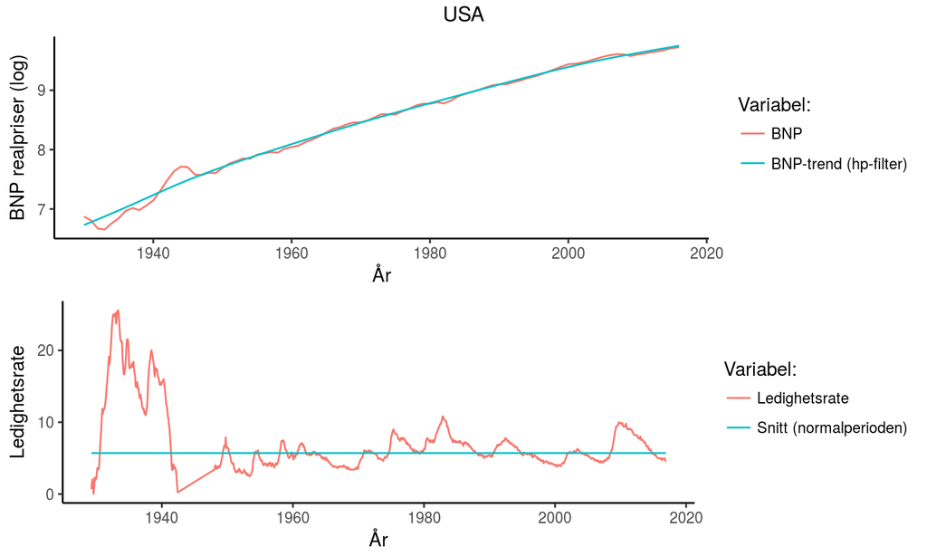

### USA 1946-2007

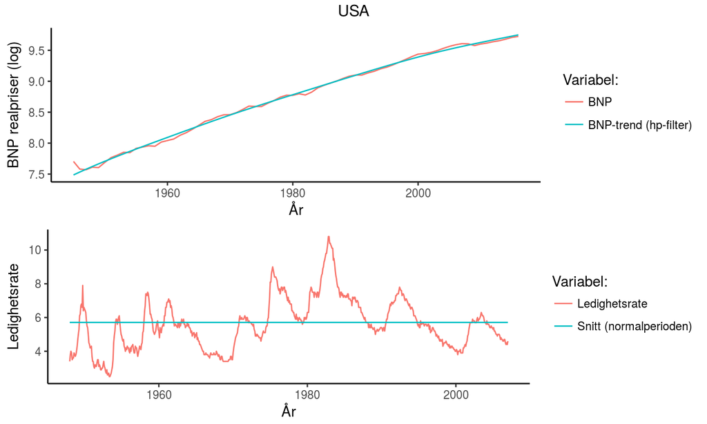

- Sentralt poeng: Makroøkonomien innehar selvkorrigerende mekanismer

### USA 1929-1939 ("The Great Depression") og 2007-2012 ("The Great Recession")

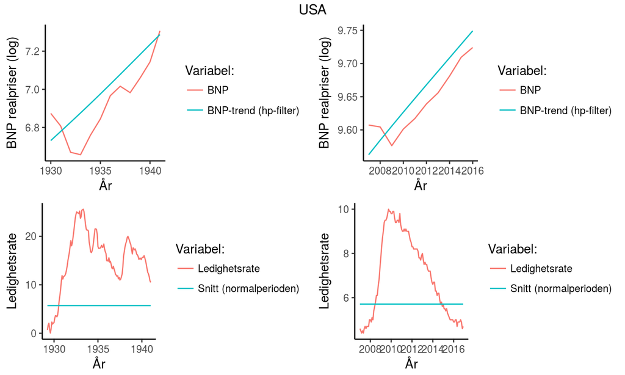

- Sentralt poeng: Makroøkonomiens selvkorrigerende mekanismer er satt ut av spill

## Tre grunnleggende spørsmål blir forsøkt besvart

1. Hva forårsaker konjunktursvingninger?
2. Hva er forklaringene bak økonomisk vekst?
3. Hvorfor oppstår økonomiske kriser?

## Og i den sammenheng, hvilken rolle bør offentlige myndigheter spille?

1. Stabiliseringspolitikk - aktiv eller passiv
2. Samfunnsinstitusjoner og graden av frie markeder
3. Bail-in (investorene tar tapene) vs. bail-out (offentlige redningspakker)

## Kjente makroøkonomer

[figure not shown]

John M. Keynes (1883-1946)

[figure not shown]

Paul Krugman(1953-)

[figure not shown]

Hyman Minsky (1919-1996)

[figure not shown]

Milton Friedman (1912-2006)

[figure not shown]

Friedrich Hayek (1899-1992)

### Politikkanbefalinger

| Økonom | Konjunktursvingninger | Stabiliseringspolitikk | Krisepolitikk |
| --- | --- | --- | --- |
| Keynes/Krugman | Investeringer (\(\Delta\overline{I}\)) 'animal spirits' | Finanspolitikk (\(\Delta G\)) | Nullrente (\(i=0\)) og ekspansiv finanspolitikk (\(\overline{G}>0\)) |
| Minsky | Økonomisk stabilitiet fører til ustabilitet | Finansreguleringer og sentralbank | Bail-out (redningspakker) |
| Friedman | Endringer i pengemengden (\(\Delta M\)) | Konstant pengemengdevekst (\(\frac{\Delta M}{M}\) = k > 0) | Nullrente (\(i=0\)) og holde pengemengden stabil |
| Hayek | Bankenes kredittvekst | Fri konkurrane i banksektoren (ingen sentralbank) | Likvidering (bail-in) |

## Abstraksjon

[Ockhams barberkniv:](https://no.wikipedia.org/wiki/Ockhams_barberkniv)

> More things should not be used than are necessary (*Entia non sunt multiplicanda praeter necessitatem*)
- Prinsippet slår fast at man ikke skal anta *flere* ting enn hva som trengs for å forklare de observasjoner som en studerer

Disse tingene vil i vårt kurs være knyttet til:

- Hvem utgjør de økonomiske aktørene i økonomien?
- Hvilken markeder er operasjonelle (\(\text{v}\) er symbolet for dette)?
- Hva er størrelsen på økonomien?

Videre, vi formulerer vi de økonomiske sammenhengene vi mener gjør seg gjeldende ved bruk av matematikk (dvs. algebraiske ligninger)

## Sentrale aktører i makroøkonomien

### Husholdninger - del I, del II og del III

- Konsumerer (\(\text{C}\)) og sparer (\(\text{S}\))

### Bedrifter - del I, del II og del III

- Produserer (\(\text{Y}\)) og investerer (\(\text{I}\))

### Finansinstitusjoner - del II, III

- Investerinsbanker: Mellomledd mellom långivere og låntakere
- Forretningsbanker: Mellomledd mellom långivere og låntakere *og* innehar kredittskapende evner \(\Rightarrow\) bestemmer lånetilbudet i økonomien

### Sentralbanken - del I og III

- Bestemmer rentenivå (\(\text{i}\)) eller pengemengden (\(\text{M}\))

### Offentlige myndigheter - del I og III

- Finanspolitikk (\(\text{G}\))

## Markedene vi studerer

### Godemarkedet (varer og tjenester)

- del I, del II og del III

### Pengemarkedet (/obligasjonsmarkedet)

- del I og del III

### Arbeidsmarkedet

- del I og del II

### Finansmarkeder

- del II kapitalmarkedet (investeringsbanker)
- del III lånemarkedet (forretningsbanker)

### Valutakursmarkedet

- del I

## Størrelsen på en økonomi

### Lukket (eller global) økonomi

- Påvirkes ikke av omverden
- Eks. på en grov tilnærming: USA

### Liten åpen økonomi

- Påvirkes av, men påvirker ikke selv omverden
- Eks. på en tilnærming: Norge

**Øvelse:** Lag et oversiktskart som summerer opp alle opplysningene knyttet til de økonomiske agentene, markedene og størrelsen på økonomien